# Canadian wind turbines

Bennour Mohamed Hsin

27/10/2020

```r
library(tidyverse)
```

In this post I will be treating the Canadian wind turbines dataset. you can check it out [here](https://github.com/rfordatascience/tidytuesday/blob/master/data/2020/2020-10-27/readme.md)

```r
wind_turbine <- readr::read_csv('https://raw.githubusercontent.com/rfordatascience/tidytuesday/master/data/2020/2020-10-27/wind-turbine.csv')
wind_turbine %>% glimpse()
```

```
## Rows: 6,698
## Columns: 15
## $ objectid                   <dbl> 1, 2, 3, 4, 5, 6, 7, 8, 9, 10, 11, 12, 13,…
## $ province_territory         <chr> "Alberta", "Alberta", "Alberta", "Alberta"…
## $ project_name               <chr> "Optimist Wind Energy", "Castle River Wind…
## $ total_project_capacity_mw  <dbl> 0.90, 44.00, 3.78, 3.78, 3.78, 3.78, 19.50…
## $ turbine_identifier         <chr> "OWE1", "CRW1", "WWT1", "WWT2", "WWT3", "W…
## $ turbine_number_in_project  <chr> "1/2", "1/60", "1/6", "2/6", "3/6", "4/6",…
## $ turbine_rated_capacity_k_w <dbl> 150, 600, 600, 600, 600, 660, 1300, 1300, …
## $ rotor_diameter_m           <dbl> 23, 44, 44, 44, 44, 47, 60, 60, 60, 60, 60…
## $ hub_height_m               <dbl> 30, 40, 50, 50, 50, 50, 46, 46, 46, 46, 46…
## $ manufacturer               <chr> "Bonus", "Vestas", "Vestas", "Vestas", "Ve…
## $ model                      <chr> "AN 150/30", "V44/600", "V44/600", "V44/60…
## $ commissioning_date         <chr> "1993", "1997", "1998", "1998", "1998", "2…
## $ latitude                   <dbl> 49.52535, 49.51264, 49.23307, 49.23303, 49…
## $ longitude                  <dbl> -114.0548, -114.0357, -113.6549, -113.6302…
## $ notes                      <chr> NA, NA, NA, NA, NA, NA, NA, NA, NA, NA, NA…
```

Now what kind of insights can we derive from this data? I am not really sure, nevertheless, the first that we need to do is try to understand what we have here. Since we have spatial data its an opportunity to work with maps then.

So let’s see where these turbines are concentrated in canda, but first, for those who don’t know let’s check the provinces first:

```r
wind_turbine %>%
  select(province_territory) %>%
  table() %>%
  prop.table() %>%
  sort(decreasing = T) %>%
  as_tibble() %>%
  mutate(n = round(n*100, 3)) %>%
  mutate(cumulative = cumsum(n)) %>%
  rename(province=".")
```

```
## # A tibble: 12 x 3
##    province                       n cumulative
##    <chr>                      <dbl>      <dbl>
##  1 Ontario                   39.8         39.8
##  2 Quebec                    29.7         69.5
##  3 Alberta                   13.4         82.9
##  4 Nova Scotia                4.63        87.5
##  5 British Columbia           4.36        91.9
##  6 Saskatchewan               2.28        94.2
##  7 Manitoba                   1.99        96.2
##  8 New Brunswick              1.78        98.0
##  9 Prince Edward Island       1.55        99.5
## 10 Newfoundland and Labrador  0.403       99.9
## 11 Northwest Territories      0.06       100.
## 12 Yukon                      0.03       100.
```

So there you go, 69% of the wind turbines in canada are installed in Ontario and Quebec. This is an interesting fact, but I think we should look up when did all this started, and how is the turbines service period is distributed.

```r
wind_turbine %>%
  select(commissioning_date) %>%
  table() %>%
  prop.table() %>%
  as_tibble() %>%
  mutate(n = round(n * 100, 3)) %>%
  arrange(desc(n)) %>%
  rename(year = ".")
```

```
## # A tibble: 35 x 2
##    year          n
##    <chr>     <dbl>
##  1 2014      13.0
##  2 2015       9.48
##  3 2013       9.27
##  4 2011       8.81
##  5 2009       7.24
##  6 2006       6.79
##  7 2012       6.03
##  8 2010       4.99
##  9 2016       3.97
## 10 2014/2015  3.09
## # … with 25 more rows
```

appearantly there is some year inputs where we don’t have one year alone but rather a two years season; like instead of havinf 2014, we have 2014/2015 as a year. My take on this will be to keep oly the first year of the combination, since the year column is presented as a text we can do this easily using :

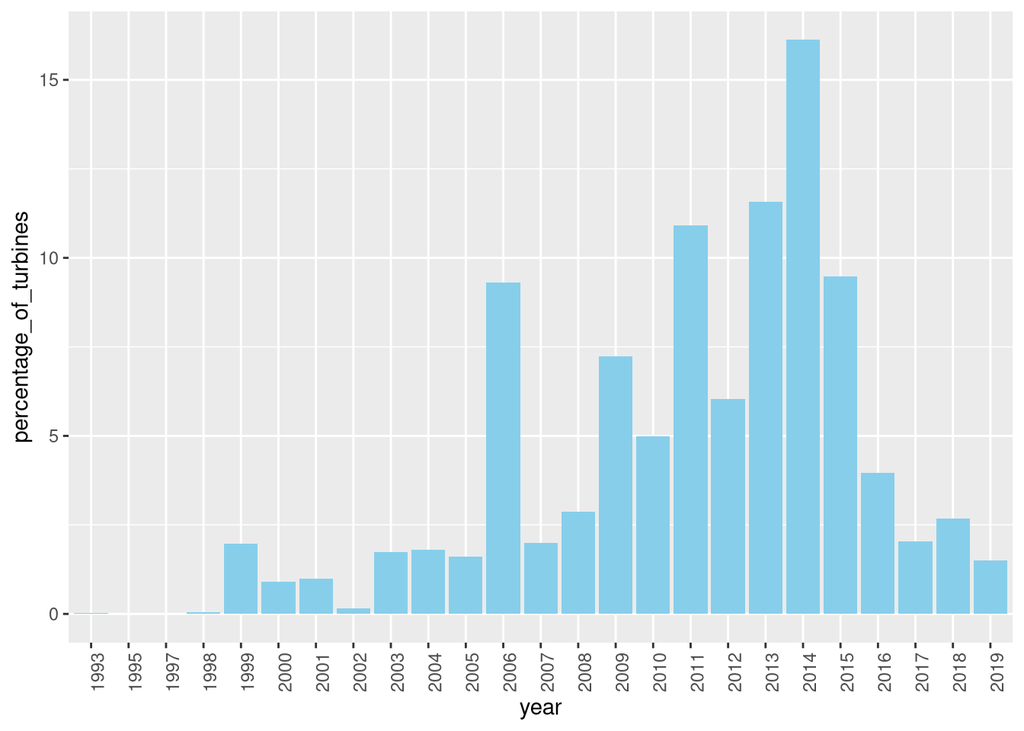

```r
wind_turbine[,12] <- wind_turbine %>%
  select(commissioning_date) %>%
  sapply(.,str_remove, "/.*") %>%
  as.numeric() %>%
  as_tibble()


wind_turbine %>%
  select(commissioning_date) %>%
  table() %>%
  prop.table() %>%
  as_tibble() %>%
  rename(year = ".") %>%
  mutate(percentage_of_turbines = round(n * 100, 3),
         year = as_factor(year)) %>%
  ggplot(aes(x = year, y = percentage_of_turbines)) +
    geom_col(fill = "skyblue") +
    theme(axis.text.x=element_text(angle=90, hjust=1, vjust = 1))
```

This is the distribution of the percentage of wind turbines commissioned over the time period of the data set. Let’s see what a descriptive summary of this distribution would give us :

```r
wind_turbine %>%
  select(commissioning_date) %>%
  table() %>%
  prop.table() %>%
  as_tibble() %>%
  rename(year = ".") %>%
  mutate(percentage_of_turbines = round(n * 100, 3),
         year = as_factor(year)) %>%
  summary()
```

```
##       year          n             percentage_of_turbines
##  1993   : 1   Min.   :0.0001493   Min.   : 0.015
##  1995   : 1   1st Qu.:0.0098537   1st Qu.: 0.985
##  1997   : 1   Median :0.0198567   Median : 1.986
##  1998   : 1   Mean   :0.0400000   Mean   : 4.000
##  1999   : 1   3rd Qu.:0.0603165   3rd Qu.: 6.032
##  2000   : 1   Max.   :0.1612422   Max.   :16.124
##  (Other):19
```

The average turbine commissioning is at 4% every year. Now how do these numbers compare province wise? An interactive map will be very usefull in this case, and frankly very chllenging as well, let’s do it anyway, let’s set the map first:

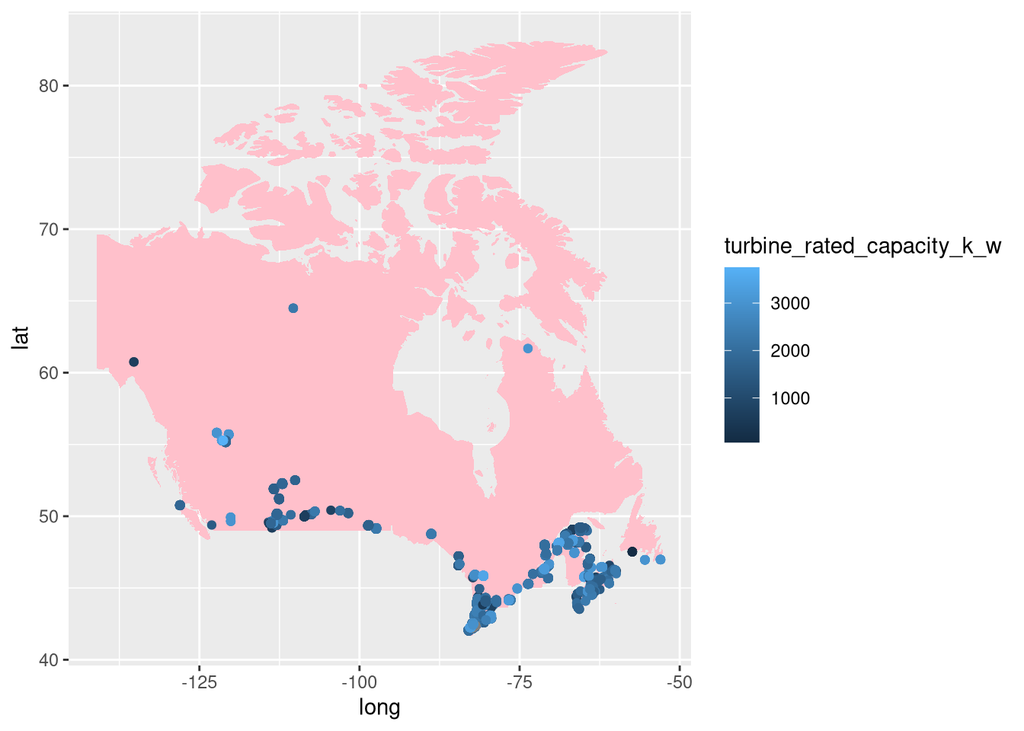

```r
library(maps)
canada <- map_data("world", region = "canada")
canada %>%
  ggplot(aes(x = long,
             y = lat)) +
    geom_polygon(aes(group = group), fill = "pink") +
    geom_point(data = wind_turbine, aes(x = longitude,
                                        y = latitude,
                                        #size = turbine_rated_capacity_k_w), alpha = 0.1)
                                        colour = turbine_rated_capacity_k_w))
```

In this graph we can see the individual capacity and concentration of turbines in each project in canada, however, a main issue that we need is how did the characteristics of each wind turbine project evolved over the period over which the data is collected. An interesting approach is using gganimate to see this.

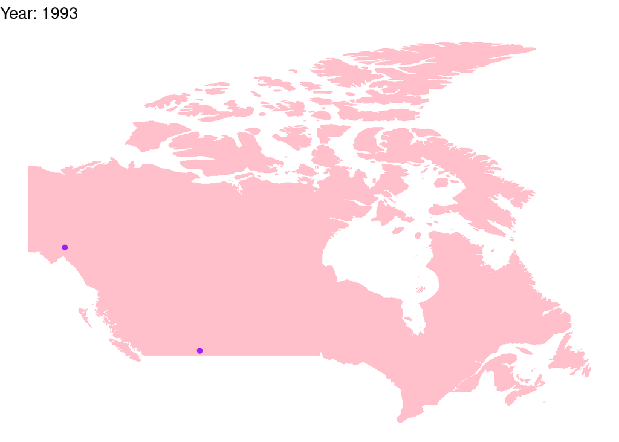

```r
library(gganimate)
library(gifski)

canada %>%
  ggplot(aes(x = long,
             y = lat)) +
    geom_polygon(aes(group = group), fill = "pink") +
    geom_point(data = wind_turbine, aes(x = longitude,
                                        y = latitude),
               color = "purple") +
    labs(title = 'Year: {closest_state}') +
    transition_states(wind_turbine$commissioning_date) +
    shadow_mark(color = 'lightgreen', size = 0.4, past = T, future = F) +
    theme_void()
```

Well, there you go guys, an animated graph that provides where wind turbines have been established in with what intensity over time.

However, these turbines are mainly established under specific projects, a good idea is to understand the characteristics of these projects and how they did evolve over time and where. For example, a province might have one project that produces higher energy than others with more projects with less turbines and less energy output. Its up to us to figure this out. Let’s get back to the data:

Let’s start with the project capacity in mega watts:

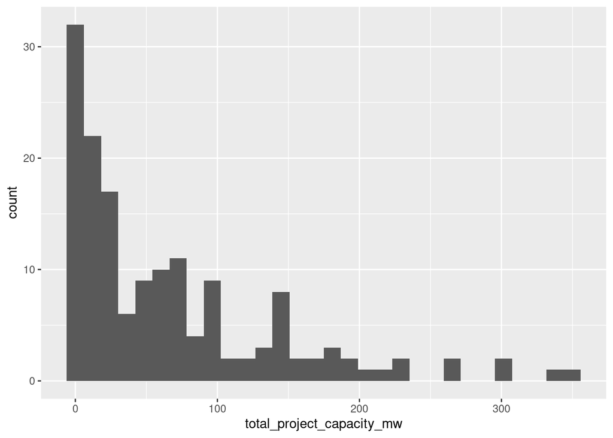

```r
wind_turbine %>%
  count(total_project_capacity_mw, sort = T) %>%
  ggplot(aes(x= total_project_capacity_mw)) +
  geom_histogram()
```

```r
wind_turbine %>%
  select(total_project_capacity_mw) %>%
  summary()
```

```
##  total_project_capacity_mw
##  Min.   :  0.3
##  1st Qu.: 70.5
##  Median :102.0
##  Mean   :134.8
##  3rd Qu.:181.5
##  Max.   :350.0
```

The descriptive statistics provides us with little information about the evolution of the project capacities over the years.

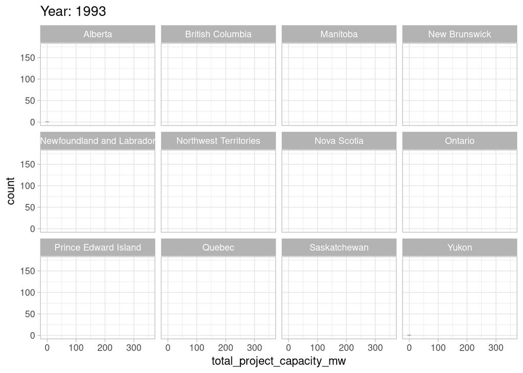

```r
wind_turbine %>%
  ggplot(aes(x = total_project_capacity_mw)) +
    geom_histogram() +
    facet_wrap(province_territory ~.) +
    labs(title = 'Year: {closest_state}') +
    transition_states(commissioning_date) +
    shadow_mark(fill = 'lightgreen', size = 0.4, past = T, future = F) +
    theme_light()
```

Oh yeah, this shows not only the evolution of the capacity over time but also on the province level, Alberta, Ontario, and Qubec are leading the way.

Now let’s look at the characterisitics of the wind turbines themsleves:

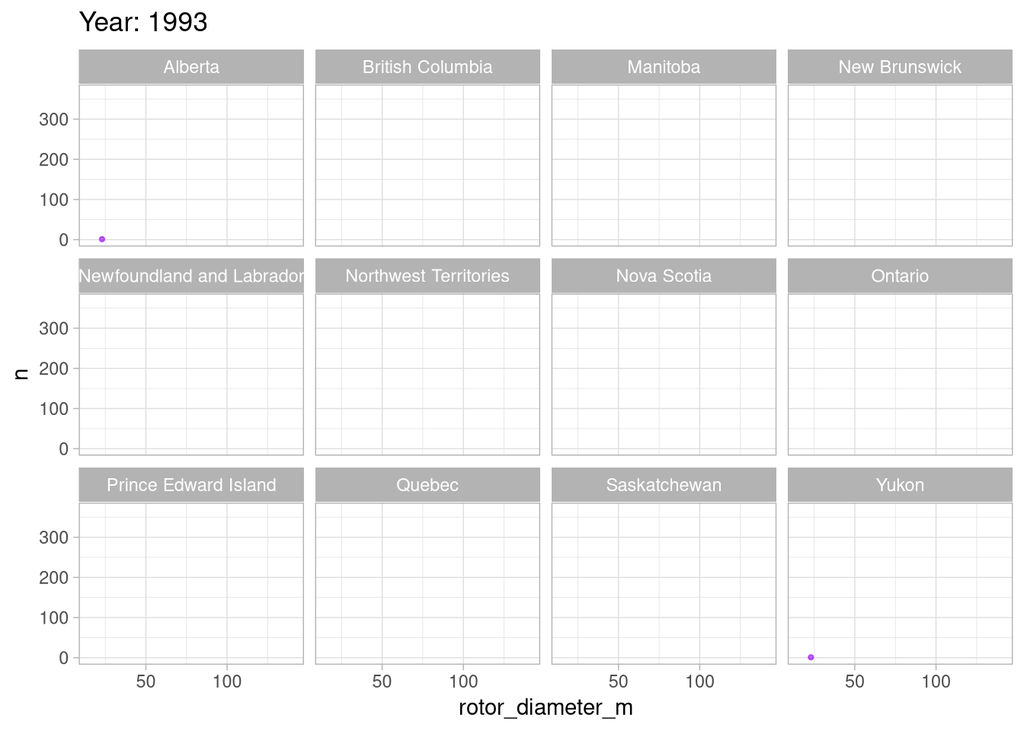

```r
wind_turbine %>%
  count(rotor_diameter_m, province_territory, commissioning_date) %>%
  ggplot(aes(x = rotor_diameter_m,
             y = n)) +
    geom_point(colour = "purple", alpha = 0.7, size= 0.8) +
    facet_wrap(province_territory~.) +
    labs(title = 'Year: {closest_state}') +
    transition_states(commissioning_date) +
    shadow_mark(colour = 'grey', size = 0.4, past = T, future = F) +
    theme_light()
```

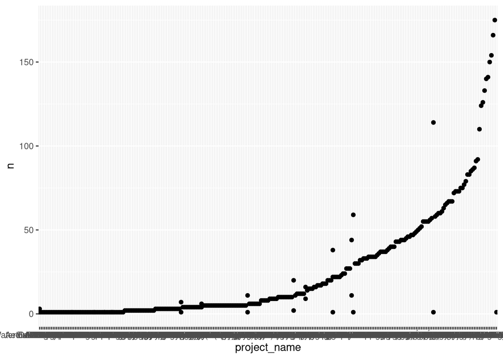

```r
wind_turbine %>%
  count(project_name, province_territory, commissioning_date,  sort = T) %>%
  mutate(project_name = as_factor(project_name)) %>%
  mutate(project_name = fct_reorder(project_name,n)) %>%
  ggplot(aes(x = project_name,
             y = n)) +
    geom_point()
```